# STS 112: Notebook 4

Mel Avina-Beltran

In this notebook, we will be working with industry variables, using column graphs to visualize how the nature of work changed between 1870 and 1930. You will learn all the skills you need to complete Lab 4:

- Using the grammar of graphics to control the appearance of your visualizations
- Making publication-quality column graphs that display multiple variables
- Recoding variables into a smaller number of categories
- Grouping and summarizing your data frame

## Exploring the data

Read in this week’s data as a data frame called `ipums`.

```r
library(tidyverse)
ipums <- read_csv("wk4.csv")
```

Explore the dataset and documentation to determine which samples and variables we are working with.

```r
names(ipums)
```

```
 [1] "YEAR"     "STATEFIP" "PERWT"    "SEX"      "AGE"      "RACE"     "RACED"    "OCC"      "OCC1950"  "IND1950"
```

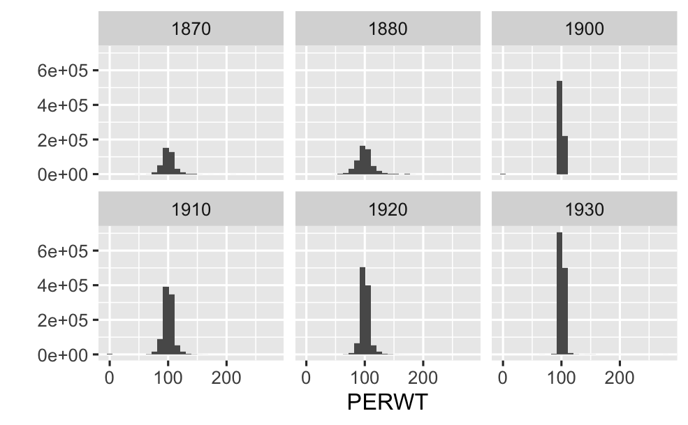

```r
qplot(PERWT, data = ipums, facets = ~YEAR)
```